# Lecture 12 Regression Discontinuity

Nick Huntington-Klein

2021-01-15

## Recap

- We’ve been going over ways in which we can use control groups to isolate causal effects
- We can select similar control groups using matching or controlling (what economists call “selection on observables”)
- We can use a treated group at a different time as its own control group with fixed effects
- When a treatment is applied at a particular time, we can select a reasonable control to account for the effects of time using difference-in-difference (a “natural experiment”)

## Today

- We’re going to go over one other way in which we can find and isolate a very convincing control group
- Like DID, it’s also an example of a natural experiment
- *Regression discontinuity*

## Regression Discontinuity

- Notice that the y-axis here is *In GATE*, not the outcome

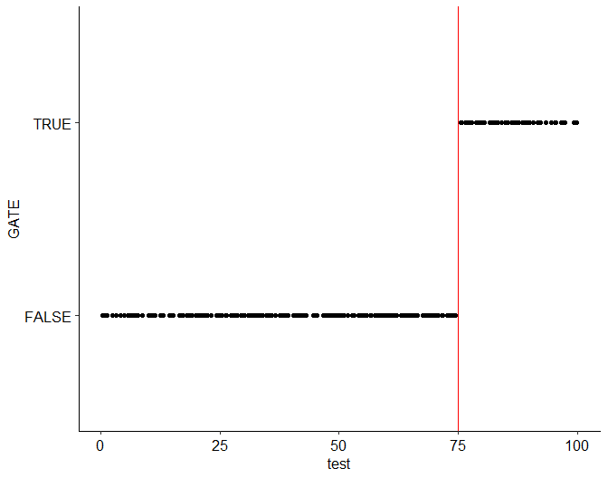

```
## $x
## [1] "Test Score"
##
## $y
## [1] "In GATE"
##
## attr(,"class")
## [1] "labels"
```

## Regression Discontinuity

- Here’s how it look when we look at the actual outcome

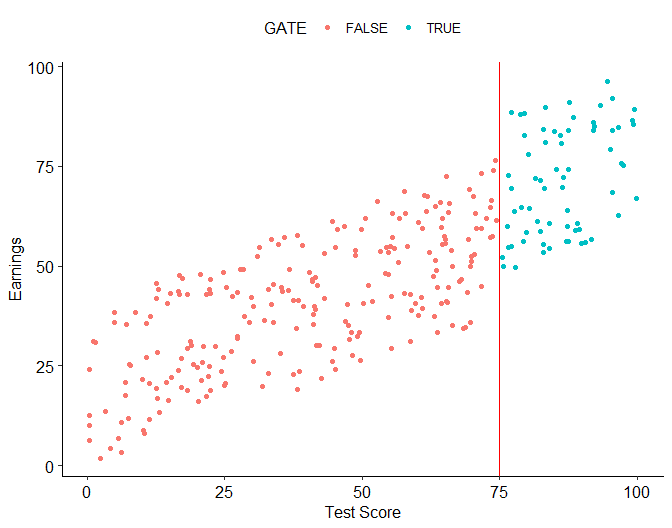

## Regression Discontinuity

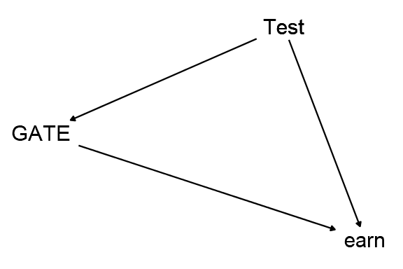

## Regression Discontinuity

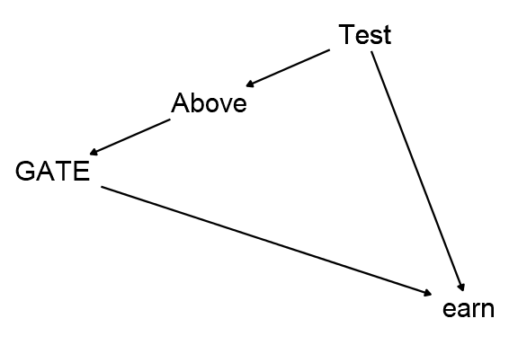

## Regression Discontinuity

- What can we do with that information?
- Well, imagine that we looked at the area *just around* the cutoff
- Say, the cutoff is 75, so we look at 73 to 77
- *Within that group*, it’s basically random whether you fall on one side of the line or another

## Regression Discontinuity

- Someone with a 75 is, on average, almost exactly the same as someone with a 76, except that one got the treatment and the other didn’t!
- Heck, that tiny test score difference could be due to just having a bad day before the test
- So we have two groups - the just-barely-missed-outs and the just-barely-made-its, that are basically exactly the same except that one happened to get treatment
- A perfect description of what we’re looking for in a control group!

## Regression Discontinuity

- So we look directly around the cutoff, and compare just below to just above.
- This is our way of controlling for test score and closing the `GATE <- Above <- Test -> earn` back door
- Why not just control for `Test` in the normal way?
- Because if we really think that, right around the cutoff, it’s random whether you’re on one side or the other, we don’t just close the `Test` back door, we have effectively random assignment, like an experiment!
- We’re not just closing the `Test` back door, we’re closing *all* back doors

## In Practice

```r
rdd.data <- tibble(test = runif(1000)*100) %>%
  mutate(GATE = test >= 75) %>% mutate(earn = runif(1000)*40+10*GATE+test/2)
#Choose a "bandwidth" of how wide around the cutoff to look (arbitrary in our example)
#Bandwidth of 2 with a cutoff of 75 means we look from 75-2 to 75+2
bandwidth <- 2
#Just look within the bandwidth
rdd <- rdd.data %>% filter(abs(75-test) < bandwidth) %>%
  #Create a variable indicating we're above the cutoff
  mutate(above = test >= 75) %>%
  #And compare our outcome just below the cutoff to just above
  group_by(above) %>% summarize(earn = mean(earn))
rdd
#Our effect looks just about right (10 is the truth)
rdd$earn[2] - rdd$earn[1]
```

```
## # A tibble: 2 x 2
##   above  earn
##   <lgl> <dbl>
## 1 FALSE  55.2
## 2 TRUE   66.0
```

```
## [1] 10.80055
```

## Graphically

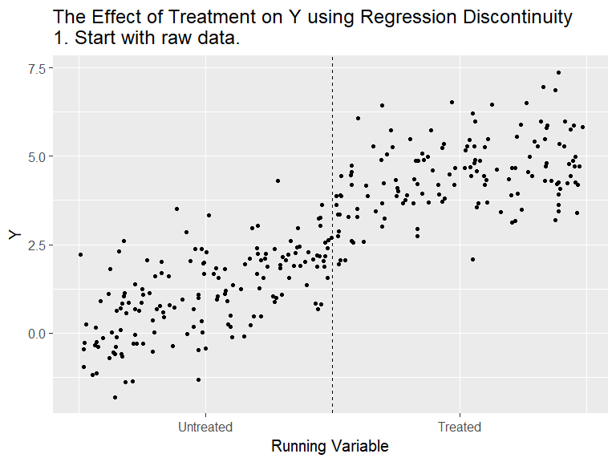

## Example: Corporate Social Responsibility

- Corporate Social Responsibility (CSR) is when corporations engage in the kind of behavior that nonprofits usually do - community outreach, charity, etc.
- Is this good for the corporation? Or would it make more sense to just send the money they spend to actual nonprofits if they just want to do good?
- This is a causal question

## Example: Corporate Social Responsibility

- Convenient for our purposes, CSR policies are voted on by shareholder boards
- If a board votes 49% in favor, it fails. 51% in favor? It passes!
- Sounds like a regression discontinuity to me!
- “Close votes” is a common application of regression discontinuity

## Example: Corporate Social Responsibility

- So how do CSR policy announcements affect stock prices?

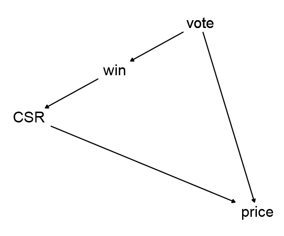

## Example: Corporate Social Responsbility

- Caroline Flammer studies this topic
- Looking at the “abnormal return” (stock price return minus what’s expected given the market) comparing CSR votes that just won vs. CSR votes that just lost
- So what should we do?
- Focus just around the cutoff and compare abnormal returns just above and just below.

## Example: Corporate Social Responsibility

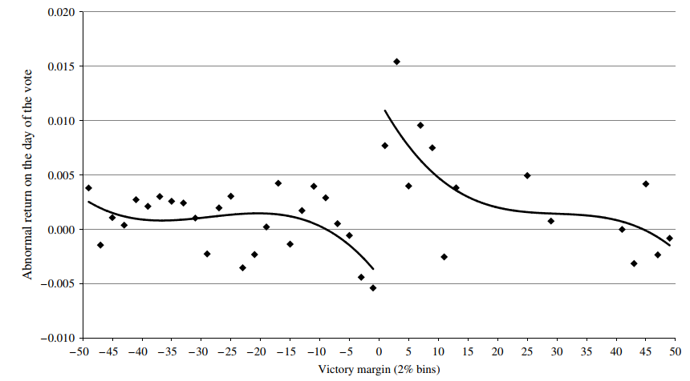

Flammer (2015) Management Science

## Balance

- Have we really closed those back doors?
- One thing that’s so great about RDD is that, since it’s basically random whether you’re on one side of the cutoff or another, there shouldn’t be other back doors
- It’s a form of within variation that’s *so narrow* it basically closes everything
- We can check this by seeing if other variables differ on either side of the line
- This is our way of testing our diagram - if our diagram is true, then `above` should have no relationship with any back door variable after focusing around the cutoff

## Balance

```r
rdd.data <- tibble(test = runif(500)*100) %>%
  mutate(backdoor=rnorm(500)+test/50) %>% mutate(GATE = test + backdoor >= 75) %>%
  mutate(earn = runif(500)*40+10*GATE+5*backdoor+test/2)
bandwidth <- 2
rdd <- rdd.data %>% filter(abs(75-test) < bandwidth) %>%
  #Create a variable indicating we're above the cutoff
  mutate(above = test >= 75) %>%
  #And compare our outcome just below the cutoff to just above
  group_by(above) %>% summarize(backdoor = mean(backdoor))
rdd
```

```
## # A tibble: 2 x 2
##   above backdoor
##   <lgl>    <dbl>
## 1 FALSE     1.22
## 2 TRUE      1.57
```

```r
#Not a lot of difference!
rdd$backdoor[2] - rdd$backdoor[1]
```

```
## [1] 0.3516092
```

## Balance

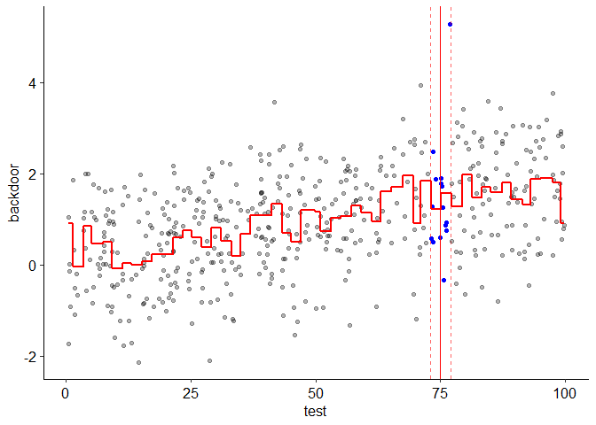

```
## $x
## [1] "Test Score"
##
## $y
## [1] "Backdoor Variable"
##
## attr(,"class")
## [1] "labels"
```

## Summing Up

- We’ve covered four main methods of making comparisons as close as possible
- Controlling and matching both take a set of measured variables and adjust so you’re looking at variation within those variables
- Difference-in-difference takes a chosen comparison group and uses it to adjust for changes over time in your treated group of interest
- Regression discontinuity uses a cutoff in a running variable to identify a treated and nontreated group that are basically randomly assigned

## Summing Up

- Next time we’ll be doing regression discontinuity using… actual regression
- We already have a solid idea of how it works, now let’s see how it’s really done

## Practice Answers

```r
#install.packages('politicaldata')
library(politicaldata)
data(house_results)

hr76 <- filter(house_results,year==1976) %>%
  mutate(repadv76 = rep - dem) %>%
  filter(!is.na(repadv76)) %>%
  select(district,repadv76)
hr16 <- filter(house_results,year==2016) %>%
  mutate(repwins16 = rep > dem) %>%
  filter(!is.na(repwins16)) %>%
  select(district,repwins16)

fulldata <- inner_join(hr76,hr16)
bandwidth <- .04

fulldata %>% filter(abs(repadv76-0)<=.04) %>%
  mutate(above = repadv76 > 0) %>%
  group_by(above) %>% summarize(repwins16=mean(repwins16))
```

```
## # A tibble: 2 x 2
##   above repwins16
##   <lgl>     <dbl>
## 1 FALSE     0.737
## 2 TRUE      0.889
```